# Virtual Internship Program

## 5. Level Encoding

```python
from sklearn.preprocessing import LabelEncoder
le = LabelEncoder()
```

```python
iris['species'] = le.fit_transform(iris['species'])
iris.head()
```

|  | sepal_length | sepal_width | petal_length | petal_width | species |
| --- | --- | --- | --- | --- | --- |
| 0 | 5.1 | 3.5 | 1.4 | 0.2 | 0 |
| 1 | 4.9 | 3.0 | 1.4 | 0.2 | 0 |
| 2 | 4.7 | 3.2 | 1.3 | 0.2 | 0 |
| 3 | 4.6 | 3.1 | 1.5 | 0.2 | 0 |
| 4 | 5.0 | 3.6 | 1.4 | 0.2 | 0 |

```python
iris.tail()
```

|  | sepal_length | sepal_width | petal_length | petal_width | species |
| --- | --- | --- | --- | --- | --- |
| 145 | 6.7 | 3.0 | 5.2 | 2.3 | 2 |
| 146 | 6.3 | 2.5 | 5.0 | 1.9 | 2 |
| 147 | 6.5 | 3.0 | 5.2 | 2.0 | 2 |
| 148 | 6.2 | 3.4 | 5.4 | 2.3 | 2 |
| 149 | 5.9 | 3.0 | 5.1 | 1.8 | 2 |

```python
iris.species
```

```
0      0
1      0
2      0
3      0
4      0
      ..
145    2
146    2
147    2
148    2
149    2
Name: species, Length: 150, dtype: int32
```

## 6. Model Training

Model training is the phase in the data science development lifecycle where practitioners try to fit the best combination of weights and bias to a machine learning algorithm to minimize a loss function over the prediction range

```python
X = iris.drop(columns='species', axis=1)
Y = iris['species']
```

```python
X_train, X_test, Y_train, Y_test = train_test_split(X, Y, test_size=0.20, stratify=Y, random_state=2)
```

```python
model = LogisticRegression()
```

```python
model.fit(X_train, Y_train)
```

```
LogisticRegression()
```

```python
# accuracy on training data
X_train_prediction = model.predict(X_train)
training_data_accuracy = accuracy_score(X_train_prediction, Y_train)
```

```python
print('Accuracy on Training data : ', training_data_accuracy*100)
```

```
Accuracy on Training data :  96.66666666666667
```

```python
# accuracy on test data
X_test_prediction = model.predict(X_test)
test_data_accuracy = accuracy_score(X_test_prediction, Y_test)
```

```python
print('Accuracy on Test data : ', test_data_accuracy*100)
```

```
Accuracy on Test data :  100.0
```

## 7. Optimal Number Of Clustring For K-Means Classification Algoritham

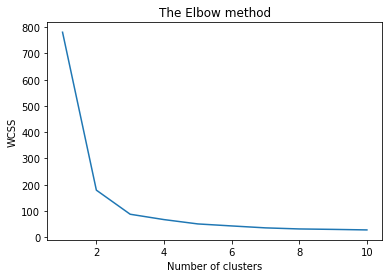

```python
# Finding the optimal number of clusters for k-means classification Algoritham

x = iris.iloc[:, [0, 1, 2, 3, 4]].values
# we import KMeans algorithm using sklearn library
from sklearn.cluster import KMeans
# we use the very first method is Elbow Method
wcss = []
# WCSS means Within Cluster Sum of Squares

for i in range(1, 11):
    kmeans = KMeans(n_clusters = i, init = 'k-means++',
                    max_iter = 300, n_init = 10, random_state = 0)
    kmeans.fit(x)
    wcss.append(kmeans.inertia_)

# plotting above result in line graph format
plt.plot(range(1, 11), wcss)
plt.title('The Elbow method')
plt.xlabel('Number of clusters')
plt.ylabel('WCSS')
plt.show()
```

In cluster analysis, the elbow method is a heuristic used in determining the number of clusters in a data set. The method consists of plotting the explained variation as a function of the number of clusters and picking the elbow of the curve as the number of clusters to use.

## 8. Applying K-MEANS Method On Given Dataset

```python
kmeans = KMeans(n_clusters=4,init='k-means++',max_iter=300,
               n_init=10,random_state=5)
y_kmeans = kmeans.fit_predict(x)
print(y_kmeans)
```

```
[1 1 1 1 1 1 1 1 1 1 1 1 1 1 1 1 1 1 1 1 1 1 1 1 1 1 1 1 1 1 1 1 1 1 1 1 1
 1 1 1 1 1 1 1 1 1 1 1 1 1 2 2 2 2 2 2 2 2 2 2 2 2 2 2 2 2 2 2 2 2 2 2 2 2
 2 2 2 3 2 2 2 2 2 2 2 2 2 2 2 2 2 2 2 2 2 2 2 2 2 2 3 3 0 3 3 0 2 0 3 0 3
 3 3 3 3 3 3 0 0 3 3 3 0 3 3 0 3 3 3 0 0 0 3 3 3 0 3 3 3 3 3 3 3 0 3 3 3 3
 3 3]
```

```python
kmeans.cluster_centers_
```

```
array([[7.42307692, 3.13076923, 6.26923077, 2.06923077, 2.        ],
       [5.006     , 3.418     , 1.464     , 0.244     , 0.        ],
       [5.9       , 2.76      , 4.25      , 1.326     , 1.02      ],
       [6.34324324, 2.93243243, 5.31351351, 2.01081081, 1.97297297]])
```

[figure not shown]

```python
# Visualizing the clusters
plt.figure(figsize = (16,9))
from matplotlib import style
style.use('ggplot')
plt.scatter(x[y_kmeans == 0,0],x[y_kmeans == 0,1],s = 100,
           c = 'blue',label = 'Iris-setosa',marker='*')
plt.scatter(x[y_kmeans == 1,0],x[y_kmeans == 1,1],s = 100,
           c = 'yellow',label = 'Iris-versicolour',marker='*')
plt.scatter(x[y_kmeans == 2,0],x[y_kmeans == 2,1],s = 100,
           c = 'red',label = 'Iris-setosa',marker='*')
plt.legend()
```

[figure not shown]

```python
# plotting Centroids of the clusters in above graph
plt.figure(figsize = (16,9))
style.use('ggplot')
plt.scatter(x[y_kmeans == 0,0],x[y_kmeans == 0,1],s = 100,
           c = 'green',label = 'Iris-setosa',marker='*')
plt.scatter(x[y_kmeans == 1,0],x[y_kmeans == 1,1],s = 100,
           c = 'blue',label = 'Iris-versicolour',marker='*')
plt.scatter(x[y_kmeans == 2,0],x[y_kmeans == 2,1],s = 100,
           c = 'yellow',label = 'Iris-setosa',marker='*')
#add centers
plt.scatter(kmeans.cluster_centers_[:,0],kmeans.cluster_centers_[:,1],
           s=100,c='red',label='Cluster_Centroids')
plt.legend()
```